# Parcial-2023

#### Calibración

Selecciona al menos 50 muestras del mismo tamaño y con el mismo diseño que la muestra utilizada en el conteo rápido. Esto es, selecciona el mismo número de casillas, usando muestreo aleatorio simple dentro de cada estrato.

- Para cada muestra calcula un intervalo del 95% de confianza usando bootstrap.
- Grafica los intervalos y calcula la proporción de ellos que contienen el verdadero valor observado. Describe tus observaciones y compara con el intervalo obtenido en el ejercicio anterior.

```r
# Establecer una semilla para reproducibilidad
set.seed(123)

# Número de muestras a generar
num_samples <- 50

# Tamaño de cada muestra (igual al tamaño de la muestra original)
sample_size <- nrow(muestra_tidy)

# Crear una lista para almacenar los resultados de los intervalos
intervalos_lista <- list()

# Valor crítico para el intervalo de confianza del 95%
valor_critico <- qnorm(0.975)

# Generar las muestras y calcular los intervalos de confianza para cada una
for (i in 1:num_samples) {
  # Realizar el remuestreo bootstrap
  muestra_bootstrap <- sample_bootstrap(muestra_tidy)

  # Inicializar una lista para almacenar los resultados de los intervalos para esta muestra
  intervalos_sample <- list()

  # Calcular el estimador de razón combinado y el error estándar para cada opción
  for (opcion in opciones) {
    datos_opcion <- muestra_bootstrap %>%
      filter(get(opcion) == 1)

    # Calcular el error estándar utilizando bootstrap
    bootstrap_se <- calcular_bootstrap_se(datos_opcion, opcion)

    # Calcular los límites del intervalo de confianza para esta opción
    limite_inferior <- resultados_lista[[opcion]] - valor_critico * bootstrap_se
    limite_superior <- resultados_lista[[opcion]] + valor_critico * bootstrap_se

    # Almacenar el resultado en la lista de intervalos para esta muestra
    intervalos_sample[[opcion]] <- c(limite_inferior, limite_superior)
  }

  # Almacenar la lista de intervalos de esta muestra en la lista principal
  intervalos_lista[[i]] <- intervalos_sample
}

# Imprimir los intervalos para una muestra
for (opcion in opciones) {
  cat("Intervalos de confianza para", opcion, "en una muestra:\n")
  for (i in 1:num_samples) {
    intervalo <- intervalos_lista[[i]][[opcion]]
    cat("Muestra", i, ":", "Límite Inferior =", intervalo[1], "Límite Superior =", intervalo[2], "\n")
  }
  cat("\n")
}
```

```
## Intervalos de confianza para SI en una muestra:
## Muestra 1 : Límite Inferior = 0.125 Límite Superior = 0.125
## Muestra 2 : Límite Inferior = 0.125 Límite Superior = 0.125
## Muestra 3 : Límite Inferior = 0.125 Límite Superior = 0.125
## Muestra 4 : Límite Inferior = 0.125 Límite Superior = 0.125
## Muestra 5 : Límite Inferior = NA Límite Superior = NA
## Muestra 6 : Límite Inferior = 0.125 Límite Superior = 0.125
## Muestra 7 : Límite Inferior = NA Límite Superior = NA
## Muestra 8 : Límite Inferior = 0.125 Límite Superior = 0.125
## Muestra 9 : Límite Inferior = 0.125 Límite Superior = 0.125
## Muestra 10 : Límite Inferior = 0.125 Límite Superior = 0.125
## Muestra 11 : Límite Inferior = NA Límite Superior = NA
## Muestra 12 : Límite Inferior = NA Límite Superior = NA
## Muestra 13 : Límite Inferior = NA Límite Superior = NA
## Muestra 14 : Límite Inferior = 0.125 Límite Superior = 0.125
## Muestra 15 : Límite Inferior = 0.125 Límite Superior = 0.125
## Muestra 16 : Límite Inferior = 0.125 Límite Superior = 0.125
## Muestra 17 : Límite Inferior = NA Límite Superior = NA
## Muestra 18 : Límite Inferior = 0.125 Límite Superior = 0.125
## Muestra 19 : Límite Inferior = 0.125 Límite Superior = 0.125
## Muestra 20 : Límite Inferior = NA Límite Superior = NA
## Muestra 21 : Límite Inferior = 0.125 Límite Superior = 0.125
## Muestra 22 : Límite Inferior = NA Límite Superior = NA
## Muestra 23 : Límite Inferior = 0.125 Límite Superior = 0.125
## Muestra 24 : Límite Inferior = 0.125 Límite Superior = 0.125
## Muestra 25 : Límite Inferior = 0.125 Límite Superior = 0.125
## Muestra 26 : Límite Inferior = 0.125 Límite Superior = 0.125
## Muestra 27 : Límite Inferior = NA Límite Superior = NA
## Muestra 28 : Límite Inferior = 0.125 Límite Superior = 0.125
## Muestra 29 : Límite Inferior = NA Límite Superior = NA
## Muestra 30 : Límite Inferior = NA Límite Superior = NA
## Muestra 31 : Límite Inferior = 0.125 Límite Superior = 0.125
## Muestra 32 : Límite Inferior = 0.125 Límite Superior = 0.125
## Muestra 33 : Límite Inferior = 0.125 Límite Superior = 0.125
## Muestra 34 : Límite Inferior = NA Límite Superior = NA
## Muestra 35 : Límite Inferior = 0.125 Límite Superior = 0.125
## Muestra 36 : Límite Inferior = 0.125 Límite Superior = 0.125
## Muestra 37 : Límite Inferior = 0.125 Límite Superior = 0.125
## Muestra 38 : Límite Inferior = 0.125 Límite Superior = 0.125
## Muestra 39 : Límite Inferior = 0.125 Límite Superior = 0.125
```

[output cut: 100 more lines]

```
## Muestra 36 : Límite Inferior = 0.007582029 Límite Superior = 0.008470926
## Muestra 37 : Límite Inferior = 0.007569079 Límite Superior = 0.008483876
## Muestra 38 : Límite Inferior = 0.007615624 Límite Superior = 0.008437331
## Muestra 39 : Límite Inferior = 0.007597687 Límite Superior = 0.008455267
## Muestra 40 : Límite Inferior = 0.00759213 Límite Superior = 0.008460825
## Muestra 41 : Límite Inferior = 0.007525616 Límite Superior = 0.008527339
## Muestra 42 : Límite Inferior = 0.007597965 Límite Superior = 0.00845499
## Muestra 43 : Límite Inferior = 0.007624304 Límite Superior = 0.008428651
## Muestra 44 : Límite Inferior = 0.007588135 Límite Superior = 0.00846482
## Muestra 45 : Límite Inferior = 0.007558342 Límite Superior = 0.008494613
## Muestra 46 : Límite Inferior = 0.007615407 Límite Superior = 0.008437548
## Muestra 47 : Límite Inferior = 0.007620752 Límite Superior = 0.008432203
## Muestra 48 : Límite Inferior = 0.007622665 Límite Superior = 0.00843029
## Muestra 49 : Límite Inferior = 0.007596131 Límite Superior = 0.008456823
## Muestra 50 : Límite Inferior = 0.007614581 Límite Superior = 0.008438374
```

#### Análisis Exploratorio

Un voto nulo corresponde a una boleta donde el ciudadano acudió a las urnas y anuló su voto.

Antes de contestar los siguiente incisos piensen que rango esperarían ver para la proporción de votos nulos en una casilla.

La proporción de votos nulos en una casilla depende de múltiples factores, (participación en la votación, la la comprensión del proceso de votar, las instrucciones que se dan en las casillas, etc). Puede ocurrir que la mayoría de los votantes emitan un voto válido, por lo que la proporción de votos nulos tiende a ser baja. Pero puede asentuarse en lugaros con contextos socioeconómicos complejos). Esperariamos que oscile entre un valor cercano al 0% y un valor relativamente bajo

- Describe la distribución de datos nulos en la muestra, y como se relaciona con el total de votos, realiza gráficas y describe tus observaciones.

```r
# Inicializar una lista para almacenar las proporciones de intervalos que contienen los valores observados
proporciones_contenidas <- list()

# Calcular la proporción de intervalos que contienen los valores observados para cada opción
for (opcion in opciones) {
  proporciones <- sapply(intervalos_lista, function(intervalo) {
    valor_observado <- resultados_lista[[opcion]]
    contiene_valor_observado <- valor_observado >= intervalo[[opcion]][1] && valor_observado <= intervalo[[opcion]][2]
    return(contiene_valor_observado)
  })

  # Almacenar las proporciones en la lista
  proporciones_contenidas[[opcion]] <- proporciones
}

# Calcular la proporción promedio de intervalos que contienen los valores observados para cada opción
proporciones_promedio <- sapply(opciones, function(opcion) {
  proporciones <- proporciones_contenidas[[opcion]]
  prop_promedio <- mean(proporciones)
  return(prop_promedio)
})

# Imprimir la proporción de intervalos que contienen los valores observados
cat("Proporción de intervalos que contienen los valores observados:\n")
```

```
## Proporción de intervalos que contienen los valores observados:
```

```r
for (opcion in opciones) {
  cat(opcion, ":", proporciones_promedio[opcion], "\n")
}
```

```
## SI : NA
## NO : 1
## NULOS : 1
```

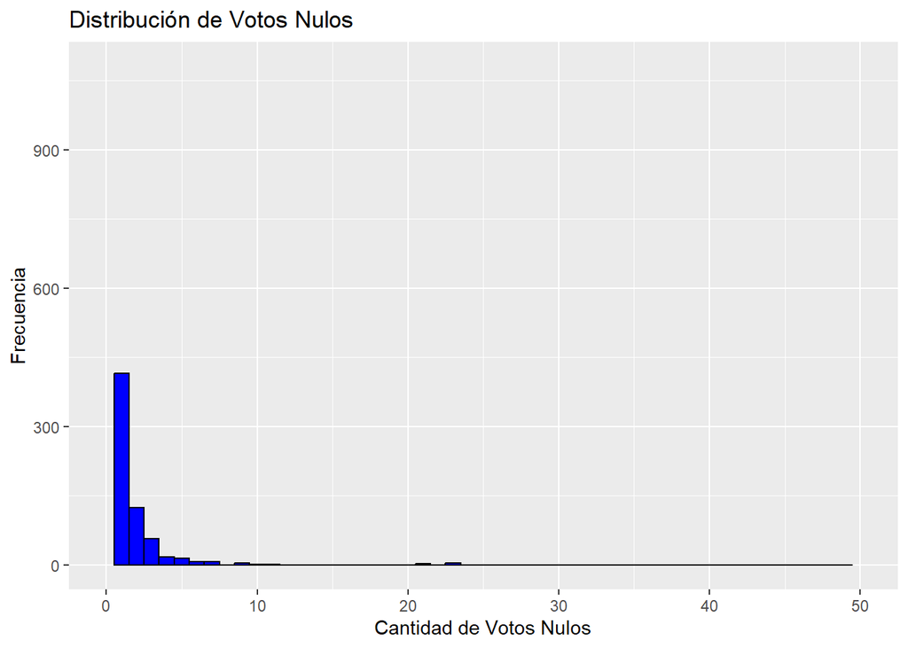

```r
ggplot(data = muestra_bootstrap, aes(x = NULOS)) +
  geom_histogram(binwidth = 1, fill = "blue", color = "black") +
  labs(title = "Distribución de Votos Nulos",
       x = "Cantidad de Votos Nulos",
       y = "Frecuencia") +
  xlim(0, 50)  # Ajusta el rango del eje x según tu preferencia
```

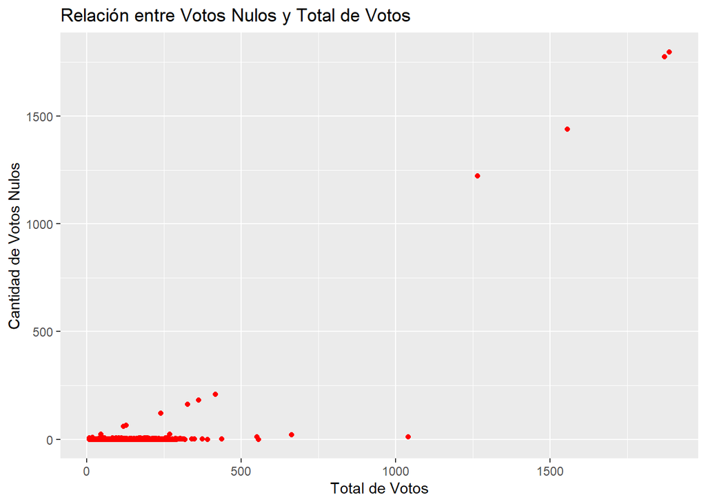

```r
ggplot(data = muestra_bootstrap, aes(x = TOTAL, y = NULOS)) +
  geom_point(color = "red") +
  labs(title = "Relación entre Votos Nulos y Total de Votos",
       x = "Total de Votos",
       y = "Cantidad de Votos Nulos")
```

- En la distribución de proporción de nulos se observan datos atípicos, ¿cuál crees que sea la razón de estas observaciones extremas? ¿consideras que se deben eliminar de la muestra antes de realizar la estimación?